# Доклад

Синхронизация времени через NTP

Виноградова М.А.

Российский университет дружбы народов, Москва, Россия

26 октября 2026

# Информация

## Докладчик

- Виноградова Мария Андреевна
- Студентка НПИбд-02-24
- Российский университет дружбы народов
- Москва, Россия

# Введение

## Актуальность темы

- Компьютеры и серверы должны работать с согласованным временем.
- Разница во времени может затруднять анализ журналов событий и поиск ошибок.
- Для автоматической синхронизации часов в сетях применяется протокол NTP.

## Цель и задачи

**Цель:** изучить принцип работы NTP и его применение для синхронизации времени в компьютерных сетях.

**Задачи:**

- Рассмотреть назначение протокола NTP.
- Изучить принцип обмена временными метками.
- Познакомиться с уровнями источников времени.
- Рассмотреть настройку синхронизации Linux.
- Изучить основные вопросы безопасности.

# Основная часть

## Что такое NTP

**NTP (Network Time Protocol)** — сетевой протокол, предназначенный для синхронизации часов компьютеров и других устройств.

NTP позволяет устройствам получать сведения о точном времени от серверов и корректировать собственные системные часы.

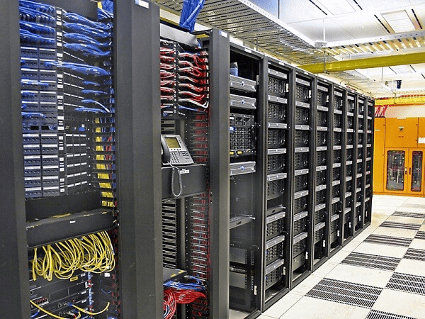

Серверное оборудование, на котором могут работать сетевые службы, включая NTP

NTP применяется в компьютерных сетях, серверной инфраструктуре и системах администрирования.

## Зачем нужна синхронизация времени

Единое время необходимо для корректной работы многих информационных систем.

- **Журналы событий:** события на разных серверах можно сопоставлять по времени.
- **Информационная безопасность:** проще анализировать последовательность действий при инцидентах.
- **Распределённые системы:** согласованное время помогает диагностировать взаимодействие сервисов.
- **Сертификаты:** корректное системное время необходимо для проверки сроков их действия.
- **Автоматизация:** задания по расписанию запускаются в соответствии с системными часами.

Даже небольшое расхождение часов может усложнить диагностику проблем, если события происходят на нескольких устройствах.

## Как работает NTP

1. Клиент отправляет запрос NTP-серверу.
2. Сервер возвращает данные, содержащие временные метки.
3. Клиент оценивает задержку передачи и разницу между своими часами и временем сервера.
4. Системные часы корректируются для уменьшения расхождения.

Для повышения точности клиент может периодически повторять обмен и сравнивать данные нескольких источников времени.

NTP не просто копирует время с другого компьютера: он учитывает особенности передачи данных и использует алгоритмы оценки качества синхронизации.

## Схема взаимодействия NTP

[figure not shown]

Клиент получает временные данные от сервера, оценивает параметры обмена и использует их для синхронизации системных часов.

## Откуда берётся точное время

[figure not shown]

Источником времени могут служить спутниковые навигационные системы, атомные часы и специализированные серверы времени.

Устройство, принимающее время от GPS, может передавать его другим системам. При этом GPS-приёмник, NTP-сервер и протокол NTP — разные понятия.

## Как NTP оценивает расхождение часов

Для оценки синхронизации используются четыре временные метки:

- **T1** — время отправки запроса клиентом;
- **T2** — время получения запроса сервером;
- **T3** — время отправки ответа сервером;
- **T4** — время получения ответа клиентом.

## Уровни источников времени — Stratum

В NTP используется система уровней, называемых **Stratum**.

| Уровень | Значение |
| --- | --- |
| Stratum 0 | Эталонные источники времени, например атомные часы или GPS-приёмники |
| Stratum 1 | Серверы, непосредственно синхронизированные с источниками Stratum 0 |
| Stratum 2 | Серверы, получающие время от Stratum 1 |
| Stratum 3 и далее | Следующие уровни серверов в иерархии синхронизации |

Чем больше номер Stratum, тем дальше сервер находится от исходного эталонного источника в данной иерархии. Однако один только номер уровня не гарантирует, что источник всегда точнее другого.

## Атомные часы как эталон времени

[figure not shown]

Лаборатория атомных часов

Атомные часы обеспечивают высокую стабильность измерения времени и используются в качестве эталонных источников.

## Выбор источника времени

При выборе NTP-сервера важно учитывать:

- надёжность и доступность источника;
- задержку сетевого соединения;
- стабильность и точность времени;
- доверие к администратору источника;
- наличие резервных источников.

В производственных сетях желательно предусматривать несколько подходящих источников времени и контролировать состояние синхронизации.

# Практическая часть

## NTP в Linux

В Linux для синхронизации времени могут использоваться разные службы. Один из распространённых вариантов — **chrony**, состоящий из службы `chronyd` и утилиты `chronyc`.

Chrony помогает синхронизировать системные часы с выбранными источниками времени и отслеживать состояние синхронизации.

## Пример настройки chrony

В конфигурационном файле `/etc/chrony.conf` или в соответствующем файле конфигурации дистрибутива можно указать источник времени:

```
server time.example.org iburst
```

`time.example.org` здесь — пример имени сервера. Перед использованием его нужно заменить на действительный и доверенный источник времени.

Параметр `iburst` позволяет выполнить начальный обмен пакетами быстрее, чтобы ускорить первичную синхронизацию.

## Запуск и проверка службы

Для систем, в которых служба называется `chronyd`, можно использовать команды:

```bash
sudo systemctl enable --now chronyd
sudo systemctl status chronyd
chronyc sources -v
chronyc tracking
```

- `enable --now` включает автоматический запуск службы и запускает её сразу.
- `status` показывает состояние службы.
- `chronyc sources -v` выводит сведения об источниках времени.
- `chronyc tracking` показывает общее состояние синхронизации и параметры системных часов.

Названия служб и расположение конфигурационных файлов могут отличаться в зависимости от дистрибутива Linux.

## Пример проверки синхронизации

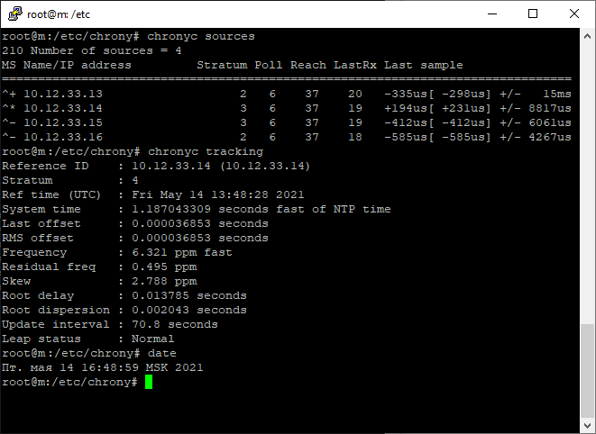

Пример вывода терминала при работе chrony

Утилиты chrony позволяют проверить, какие источники времени доступны, какой источник выбран и насколько системные часы согласованы с ним.

При диагностике следует обращать внимание на доступность источников, состояние синхронизации и величину оценочного смещения часов.

# Безопасность и сравнение

## Безопасность NTP

При настройке синхронизации времени важно учитывать возможные угрозы:

- подмену данных о времени;
- использование недоверенного сервера;
- сетевые атаки на службу NTP;
- ошибки конфигурации и недоступность источников.

Для снижения рисков следует использовать доверенные источники времени, ограничивать ненужный сетевой доступ, своевременно обновлять программное обеспечение и контролировать состояние службы.

В подходящих конфигурациях можно применять механизмы аутентификации, поддерживаемые используемой реализацией NTP.

## NTP и PTP

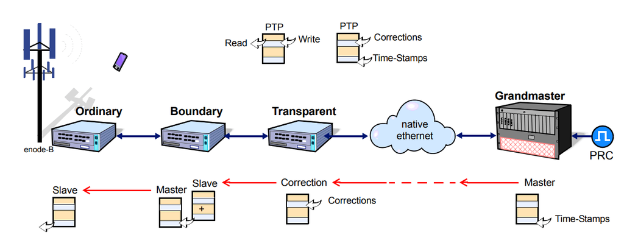

Схема PTP: Grandmaster, Boundary, Transparent и Ordinary Clock (IEEE 1588)

Выбор протокола зависит от требуемой точности, возможностей оборудования и условий эксплуатации.

# Заключение

## Основные выводы

- NTP — протокол синхронизации часов устройств в компьютерных сетях.
- Для оценки расхождения времени используются временные метки и параметры сетевого обмена.
- Источники времени организованы в иерархию уровней Stratum.
- В Linux синхронизацию можно настроить и проверить с помощью chrony.
- Надёжность синхронизации зависит от качества источников, сетевых условий и правильной конфигурации.
- Безопасность требует использования доверенных источников и контроля доступа.

# Список литературы

1. ALT Linux. Документация по настройке NTP. Электронный ресурс.
2. Yandex Cloud. Документация по синхронизации времени. Электронный ресурс.
3. ArchWiki. System time. Электронный ресурс.
4. IBM Documentation. Chrony. Электронный ресурс.